# Unicorn Companies EDA Analysis slides

### QUANTITATIVE AND VISUAL EXPLORATORY DATA ANALYSIS OF COMPANIES THAT ATTAINED UNICORN STATUS.

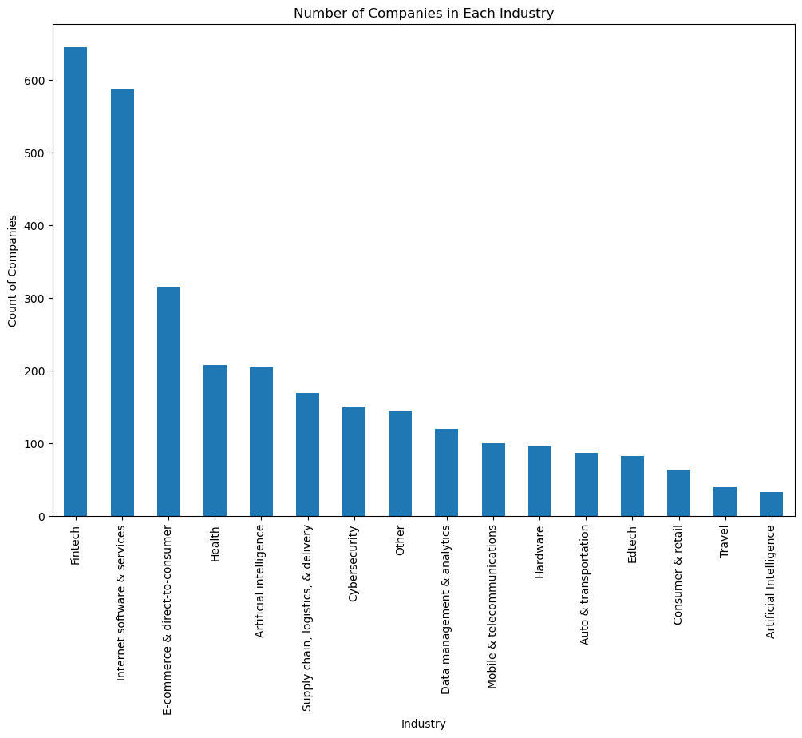

```python
#Using bar chart to visualise the numbers of unicorn companies in each industry

# Group the data by industry and count the number of companies in each group
industry_counts = uc.groupby('Industry').size()

# Sort the industry counts in descending order
industry_counts = industry_counts.sort_values(ascending=False)

# Create the bar chart
industry_counts.plot(kind='bar', figsize=(12,8))



# Set the title of the chart
plt.title('Number of Companies in Each Industry')

# Set the x-axis and y-axis labels
plt.xlabel('Industry')
plt.ylabel('Count of Companies')

# Show the chart
plt.show()
```

### BIVARATE ANALYSIS

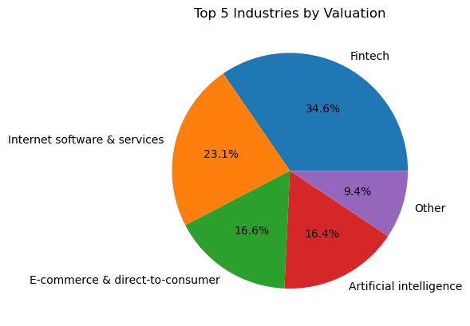

```python
## Using Pie chart to visualize the top 5 industries based on valuation of a unicorn company in their respective industry

# Group the dataframe by industry and sum the valuation for each group

uc_sum = uc.groupby('Industry')['Valuation'].sum().reset_index()

# Sort the dataframe by valuation in descending order and select the top 5 industries
uc_top5 = uc_sum.sort_values('Valuation', ascending=False).head(5)

# Create a pie chart using matplotlib
plt.pie(uc_top5['Valuation'], labels=uc_top5['Industry'], autopct='%1.1f%%')
plt.title('Top 5 Industries by Valuation')
plt.show()
```

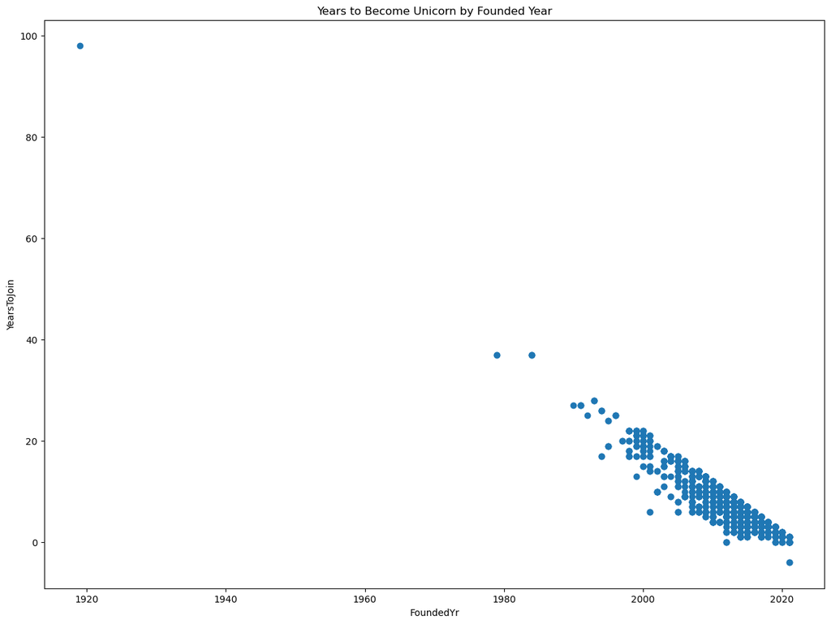

```python
## Using scatter plot to show the relationship between the Year a company was founded and
   the years it took to attain unicorn status
# Create a scatter plot using matplotlib

plt.figure(figsize=(15, 11))
plt.scatter(uc['FoundedYr'], uc['YearsToJoin'])
plt.xlabel('FoundedYr')
plt.ylabel('YearsToJoin')
plt.title('Years to Become Unicorn by Founded Year')
plt.show()
```

### MULTIVARIATE ANALYSIS

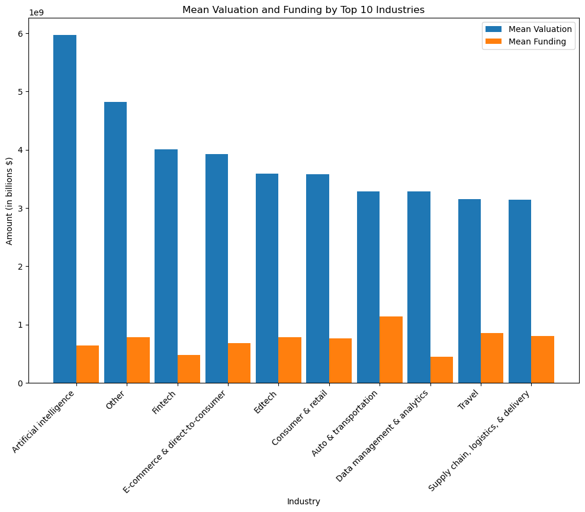

```python
## Grouped Bar chart show how the valuation and funding of companies vary across the top 10 industries(based by Valuation)

# Group the data by industry and compute the mean valuation and funding for each group
grouped_uc = uc.groupby('Industry').agg({'Valuation': 'mean', 'Funding': 'mean'})

# Get the top 10 industries based on mean valuation
top_industries = grouped_uc.nlargest(10, 'Valuation')

# Get the list of industries and the number of industries
industries = top_industries.index.tolist()
num_industries = len(industries)

# Get the mean valuation and funding for each industry
mean_valuation = top_industries['Valuation'].tolist()
mean_funding = top_industries['Funding'].tolist()

# Set the width of each bar
bar_width = 0.45

# Set the positions of the x-axis tick labels
tick_positions = np.arange(num_industries)

# Create a figure and axis object with larger size
fig, ax = plt.subplots(figsize=(12, 8))

# Create the first set of bars for mean valuation
ax.bar(tick_positions, mean_valuation, bar_width, label='Mean Valuation')

# Create the second set of bars for mean funding
ax.bar(tick_positions + bar_width, mean_funding, bar_width, label='Mean Funding')

# Add labels, title, and legend to the chart
ax.set_xlabel('Industry')
ax.set_ylabel('Amount (in billions $)')
ax.set_title('Mean Valuation and Funding by Top 10 Industries')
ax.set_xticks(tick_positions + bar_width / 2)
ax.set_xticklabels(industries)

# Set x-axis tick labels with rotation
ax.set_xticklabels(industries, rotation=45, ha='right')

ax.legend()

# Show the chart
plt.show()
```

## #

The Artificial Intelligence industry has the best risk to reward ratio if based on the average funding and average valuation data

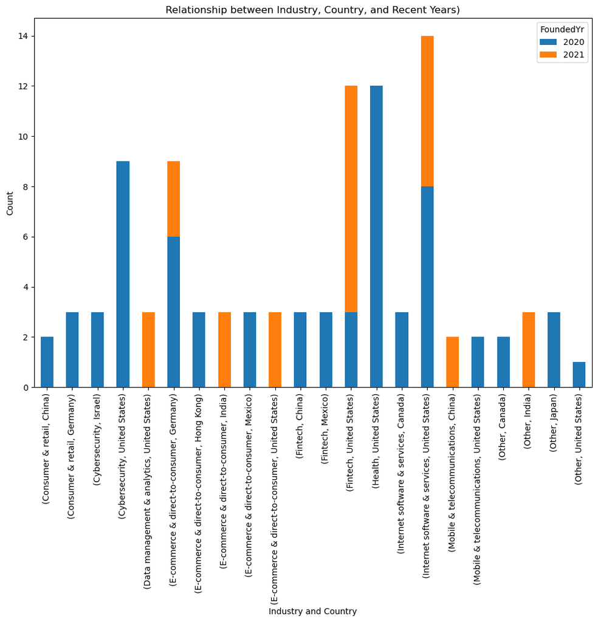

```python
## Using stacked Bar chart to visualise the industry and country most investors are investing in the past 2 years

# Filter the data to only include rows with founded year in 2020 or 2021
filtered_uc = uc[(uc['FoundedYr'] == 2020) | (uc['FoundedYr'] == 2021)]

# Group the filtered data by industry, country, and founded year
grouped_uc = filtered_uc.groupby(['Industry', 'Country', 'FoundedYr']).size().unstack(fill_value=0)

# Create the stacked bar chart
grouped_uc.plot(kind='bar', stacked=True, figsize=(12,8))

# Set the title of the chart
plt.title('Relationship between Industry, Country, and Recent Years)')

# Set the x-axis and y-axis labels
plt.xlabel('Industry and Country')
plt.ylabel('Count')

# Show the chart
plt.show()
```

### RECOMMENDATIONS

Based on the data the below are my recommendations.

- The Pie chart shows that the top 4 industries with the highest valuations over time are Fintech,internet software & services, Ecommerce & direct-to-consumer,Artificial Intelligence industries so i recommend investors focusing on those industries

-The Artificial Intelligence Industry has a better risk to reward ratio.

-Data told us most of the unicorn companies were founded in the united states and from the stacked bar chart we can observe that in the year 2021 the fintech industry ,Ecommerce & direct-to-consumer,internet software & services industry was where the focus was on, whereas in 2020 the go to industry was Cybersecurity, Health and internet software & services

I recommend a diversification of portfolio for any interested investor who wants to fund a start up company with the below percentages

25%-Fintech Industry 25% -Internet Software and Services 20% -Ecommerce and Direct to Consumer 20%- Artificial Intelligence 10%- Cybersecurity

I recommend the company should be located in the united states,and the wait time for such companies to reach unicorn status should be between 3 and 8 years